# ocean_3_nov

```python
import pandas as pd
```

```python
dataset = pd.read_csv('scotland_dataset.csv')
```

```python
#inspecting the dataset
dataset.head()
```

|  | Property_UPRN | Postcode | POST_TOWN | Date of Assessment | Primary Energy Indicator (kWh/m²/year) | Total floor area (m²) | Current energy efficiency rating | Current energy efficiency rating band | Potential Energy Efficiency Rating | Potential energy efficiency rating band | ... | Total current energy costs over 3 years (£) | Current heating costs over 3 years (£) | Potential heating costs over 3 years (£) | Current hot water costs over 3 years (£) | Potential hot water costs over 3 years (£) | Current lighting costs over 3 years (£) | Potential lighting costs over 3 years (£) | Part 1 Construction Age Band | Built Form | Property Type |
| --- | --- | --- | --- | --- | --- | --- | --- | --- | --- | --- | --- | --- | --- | --- | --- | --- | --- | --- | --- | --- | --- |
| 0 | 1.001101e+09 | EH4 5EZ | EDINBURGH | 01/01/2021 | 375.0 | 94.0 | 53.0 | E | 85.0 | B | ... | 3789.0 | 2922.0 | 1548.0 | 645.0 | 219.0 | 222.0 | 222.0 | 1930-1949 | Semi-Detached | House |
| 1 | 1.001951e+09 | EH7 4HE | EDINBURGH | 01/01/2021 | 250.0 | 175.0 | 66.0 | D | 80.0 | C | ... | 4635.0 | 4068.0 | 3015.0 | 246.0 | 246.0 | 321.0 | 321.0 | 1919-1929 | End-Terrace | House |
| 2 | 1.000996e+09 | EH4 2DL | EDINBURGH | 02/01/2021 | 403.0 | 72.0 | 61.0 | D | 78.0 | C | ... | 3570.0 | 2226.0 | 1191.0 | 1038.0 | 564.0 | 306.0 | 207.0 | 1965-1975 | Semi-Detached | Flat |
| 3 | 1.001257e+09 | PH1 1SA | PERTH | 02/01/2021 | 174.0 | 96.0 | 76.0 | C | 87.0 | B | ... | 2049.0 | 1554.0 | 1554.0 | 258.0 | 177.0 | 237.0 | 237.0 | 1999-2002 | Mid-Terrace | House |
| 4 | 1.235709e+09 | G78 1QN | Glasgow | 02/01/2021 | 145.0 | 58.0 | 79.0 | C | 79.0 | C | ... | 1212.0 | 828.0 | 828.0 | 216.0 | 216.0 | 168.0 | 168.0 | before 1919 | Mid-Terrace | Flat |

5 rows × 48 columns

```python
dataset.columns
```

```
Index(['Property_UPRN', 'Postcode', 'POST_TOWN', 'Date of Assessment',
       'Primary Energy Indicator (kWh/m²/year)', 'Total floor area (m²)',
       'Current energy efficiency rating',
       'Current energy efficiency rating band',
       'Potential Energy Efficiency Rating',
       'Potential energy efficiency rating band',
       'Current Environmental Impact Rating',
       'Current Environmental Impact Rating Band',
       'Potential Environmental Impact Rating',
       'Potential Environmental Impact Rating Band',
       'CO2 Emissions Current Per Floor Area (kg.CO2/m²/yr)',
       'WALL_DESCRIPTION', 'WALL_ENERGY_EFF', 'ROOF_DESCRIPTION',
       'ROOF_ENERGY_EFF', 'FLOOR_DESCRIPTION', 'FLOOR_ENERGY_EFF',
       'FLOOR_ENV_EFF', 'WINDOWS_DESCRIPTION', 'WINDOWS_ENERGY_EFF',
       'WINDOWS_ENV_EFF', 'MAINHEAT_DESCRIPTION', 'MAINHEAT_ENERGY_EFF',
       'MAINHEAT_ENV_EFF', 'MAINHEATCONT_DESCRIPTION', 'MAINHEATC_ENERGY_EFF',
       'MAINHEATC_ENV_EFF', 'HOT_WATER_ENERGY_EFF', 'HOT_WATER_ENV_EFF',
       'LIGHTING_DESCRIPTION', 'LIGHTING_ENERGY_EFF', 'LIGHTING_ENV_EFF',
       'Current Emissions (T.CO2/yr)',
       'Potential Reduction in Emissions (T.CO2/yr)',
       'Total current energy costs over 3 years (£)',
       'Current heating costs over 3 years (£)',
       'Potential heating costs over 3 years (£)',
       'Current hot water costs over 3 years (£)',
       'Potential hot water costs over 3 years (£)',
       'Current lighting costs over 3 years (£)',
       'Potential lighting costs over 3 years (£)',
       'Part 1 Construction Age Band', 'Built Form', 'Property Type'],
      dtype='object')
```

```python
town_efficiency = dataset.groupby(['POST_TOWN'])['Current energy efficiency rating'].mean()
```

```python
#noticing that the same town can appear multiple times
town_efficiency
```

```
POST_TOWN
ABERDEEN          68.413096
ABERDEEN          82.000000
ABERDEENSHIRE     83.250000
ABERFELDY         63.464567
ABERLOUR          62.445122
                    ...
Wick              70.650000
Wigtown           34.000000
Winchburgh        88.809524
Wishaw            76.875000
barlochan         39.000000
Name: Current energy efficiency rating, Length: 990, dtype: float64
```

```python
dataset.POST_TOWN.unique()
```

```
array(['EDINBURGH ', 'PERTH ', 'Glasgow ', 'DOLLAR ', 'GLASGOW ',
       'LARBERT ', 'THORNHILL ', 'HADDINGTON ', 'DUNBAR ', 'DUNDEE ',
       'FORRES ', 'LEVEN ', 'CALLANDER ', 'KILWINNING ', 'PRESTWICK ',
       'INVERURIE ', 'ABERDEEN ', 'STONEHAVEN ', 'LONGNIDDRY ',
       'EAST LINTON ', 'GREENOCK ', 'BRODICK ', 'STRATHCARRON ',
       'ERSKINE ', 'SPEAN BRIDGE ', 'TRANENT ', 'LIVINGSTON ',
       'FRASERBURGH ', 'STORNOWAY ', 'NORTH BERWICK ', 'AUCHTERARDER ',
       'Aberdeen ', 'PETERHEAD ', 'COATBRIDGE ', 'BANCHORY ', 'BATHGATE ',
       'Laurencekirk ', 'Edinburgh ', 'Dalkeith ', 'PAISLEY ',
       'DUNFERMLINE ', 'ROSLIN ', 'PENICUIK ', 'BERWICK UPON TWEED ',
       'ELGIN ', 'GLENROTHES ', 'DUMBARTON ', 'CUPAR ', 'WISHAW ',
       'MUSSELBURGH ', 'DENNY ', 'KILMARNOCK ', 'FALKIRK ', 'WESTHILL ',
       'GIRVAN ', 'STIRLING ', 'JOHNSTONE ', 'ELLON ', 'AYR ', 'TROON ',
       'KIRKCALDY ', 'GOREBRIDGE ', 'ARBROATH ', 'KINROSS ', 'HAMILTON ',
       'CLYDEBANK ', 'INVERNESS ', 'AIRDRIE ', 'FOCHABERS ',
       'HELENSBURGH ', 'DUMFRIES ', 'DUNBLANE ', 'LOSSIEMOUTH ',
       'KIRRIEMUIR ', 'KILMACOLM ', 'MOTHERWELL ', 'BIGGAR ', 'DUNOON ',
       'GOUROCK ', 'BEITH ', "BO'NESS ", 'BLAIRGOWRIE ', 'CURRIE ',
       'PRESTONPANS ', 'BONNYBRIDGE ', 'TILLICOULTRY ', 'WEST KILBRIDE ',
       'CRIEFF ', 'RENFREW ', 'GALSTON ', 'DALKEITH ', nan, 'LARKHALL ',
       'SHOTTS ', 'IRVINE ', 'East Lothian ', 'Fife ', 'GRANGEMOUTH ',
       'KIRKCUDBRIGHT ', 'TIGHNABRUAICH ', 'Angus ', 'Inverclyde ',
       'BROXBURN ', 'HUMBIE ', 'KEITH ', 'BONNYRIGG ', 'Invergordon ',
       'NEWMILNS ', 'ALLOA ', 'ALEXANDRIA ', 'OBAN ', 'LINLITHGOW ',
       'ST ANDREWS ', 'MENSTRIE ', 'INNERLEITHEN ', 'CUMNOCK ',
       'MONTROSE ', 'ULLAPOOL ', 'FORFAR ', 'CASTLE DOUGLAS ',
       'ANSTRUTHER ', 'LANARK ', 'HUNTLY ', 'TAIN ', 'MILLTIMBER ',
       'COWDENBEATH ', 'TAYPORT ', 'LOCHGILPHEAD ', 'ANNAN ', 'ABERLOUR ',
       'JEDBURGH ', 'BELLSHILL ', 'BRECHIN ', 'BUCKIE ', 'ALFORD ',
       'BANFF ', 'DINGWALL ', 'Inverness ', 'ISLE OF LEWIS ',
       'Musselburgh ', 'Hamilton ', 'MUIR OF ORD ', 'Midlothian ',
       'BURNTISLAND ', 'Ormiston ', 'BISHOPTON ', 'SOUTH QUEENSFERRY ',
       'PORTREE ', 'North Ayrshire ', 'Montrose ', 'LAUDER ',
       'STEVENSTON ', 'DORNOCH ', 'HERIOT ', 'KIRKLISTON ', 'PEEBLES ',
       'LOCHGELLY ', 'AVIEMORE ', 'ROY BRIDGE ', 'CROMARTY ',
       'SALTCOATS ', 'NEWPORT ON TAY ', 'FORT WILLIAM ', 'CARLUKE ',
       'ISLE OF BUTE ', 'DUNS ', 'LARGS ', 'STRANRAER ', 'KIRKWALL ',
       'INVERGORDON ', 'HALKIRK ', 'WICK ', 'GALASHIELS ', 'EYEMOUTH ',
       'LANGHOLM ', 'LOCHWINNOCH ', 'NEWTON STEWART ', 'SHETLAND ',
       'KELTY ', 'ORKNEY ', 'St Andrews ', 'Gullane ', 'FORTROSE ',
```

[output cut: 177 more lines]

```
       'North Lanarkshire ', 'Isle of Scalpy ', 'Craigellachie ',
       'Banknock ', 'Cumbrae ', 'Drumndadrochit ', 'Giffnock ',
       'BLINDWELLS ', 'By Ayr ', 'Glengarnock ', 'Orkney  ', 'Meigle ',
       'Berriedale ', 'Strathcarron   ', 'Isle Of South Uist ',
       'Uplawmoor ', 'North  Middleton ', 'Firth ',
       'East Dunbartonshire ', 'Lower Foyers ', 'Acharcle ', 'OXTON ',
       'West Post ', 'Cardross ', 'EAST RENFREWSHIRE  ', 'Drymen ',
       'ARGYLL ', 'Bridge Of  Weir Road ', 'Malaig ', 'TROON  ',
       'Uddingston  ', 'ISLE OF ARRAN  ', 'Brighouse Bay  ',
       'barlochan  ', 'Guardbridge ', 'COUSLAND  ', 'Edingburgh ',
       'ABERLOUR  ', 'DUNDONALD ', 'Kilmarnock  ', 'Road BIshopton ',
       'Ardfern ', 'Bathgate  ', 'Arbroath  ', 'Saltcoats  ', 'Inverkip ',
       'Innerleithen  ', 'Pumpherston ', 'ABERDEEN  ',
       'Quarriers Village ', 'Ayton ', 'ROTHIENORMAN ', 'Sorn ',
       'Lochearnhead '], dtype=object)
```

```python
len(dataset.POST_TOWN.unique())
```

```
991
```

```python
dataset['POST_TOWN'] = dataset.POST_TOWN.astype(str).str.lower()
```

```python
len(dataset.POST_TOWN.unique())
```

```
692
```

```python
dataset['POST_TOWN'] = dataset['POST_TOWN'].str.replace('edingburgh','edinburgh')
```

```python
len(dataset.POST_TOWN.unique())
```

```
691
```

```python
dataset.isnull().sum()
```

```
Property_UPRN                                               0
Postcode                                                    0
POST_TOWN                                                   0
Date of Assessment                                          0
Primary Energy Indicator (kWh/m²/year)                      0
Total floor area (m²)                                       0
Current energy efficiency rating                            0
Current energy efficiency rating band                       0
Potential Energy Efficiency Rating                          0
Potential energy efficiency rating band                     0
Current Environmental Impact Rating                         0
Current Environmental Impact Rating Band                    0
Potential Environmental Impact Rating                       0
Potential Environmental Impact Rating Band                  0
CO2 Emissions Current Per Floor Area (kg.CO2/m²/yr)         0
WALL_DESCRIPTION                                            0
WALL_ENERGY_EFF                                             0
ROOF_DESCRIPTION                                            0
ROOF_ENERGY_EFF                                         39235
FLOOR_DESCRIPTION                                           0
FLOOR_ENERGY_EFF                                       117202
FLOOR_ENV_EFF                                          117202
WINDOWS_DESCRIPTION                                         0
WINDOWS_ENERGY_EFF                                          0
WINDOWS_ENV_EFF                                             0
MAINHEAT_DESCRIPTION                                        0
MAINHEAT_ENERGY_EFF                                         0
MAINHEAT_ENV_EFF                                            0
MAINHEATCONT_DESCRIPTION                                    0
MAINHEATC_ENERGY_EFF                                        0
MAINHEATC_ENV_EFF                                           0
HOT_WATER_ENERGY_EFF                                        0
HOT_WATER_ENV_EFF                                           0
LIGHTING_DESCRIPTION                                        0
LIGHTING_ENERGY_EFF                                         0
LIGHTING_ENV_EFF                                            0
Current Emissions (T.CO2/yr)                                0
Potential Reduction in Emissions (T.CO2/yr)                 0
Total current energy costs over 3 years (£)                 0
Current heating costs over 3 years (£)                      0
Potential heating costs over 3 years (£)                    0
Current hot water costs over 3 years (£)                    0
Potential hot water costs over 3 years (£)                  0
Current lighting costs over 3 years (£)                     0
Potential lighting costs over 3 years (£)                   0
Part 1 Construction Age Band                            29972
Built Form                                                622
Property Type                                               0
dtype: int64
```

```python
town_efficiency = dataset.groupby(['POST_TOWN'])['Current energy efficiency rating'].mean()
```

```python
dataset['POST_TOWN'] = dataset['POST_TOWN'].str.rstrip()
```

```python
len(dataset.POST_TOWN.unique())
```

```
665
```

# Part 1: Rankings

## 1 Rank Towns by Current Energy Efficiency Rating

```python
town_efficiency = dataset.groupby(['POST_TOWN'])['Current energy efficiency rating'].mean().reset_index(name='Mean')
town_efficiency = town_efficiency.sort_values(by='Mean', ascending=False ).reset_index(drop=True)
town_efficiency.head(5)
```

|  | POST_TOWN | Mean |
| --- | --- | --- |
| 0 | gartocharn | 115.000000 |
| 1 | bannockburn | 111.750000 |
| 2 | gatehouse of fleet | 101.000000 |
| 3 | north lanarkshire | 97.117647 |
| 4 | south aryshire | 96.000000 |

## 2 Rank Towns by potential energy efficiency rating

```python
town_potential_eff = dataset.groupby(['POST_TOWN'])['Potential Energy Efficiency Rating'].mean().reset_index(name='Mean')
town_potential_eff=  town_potential_eff.sort_values(by='Mean', ascending=False).reset_index(drop=True)
town_potential_eff.head(5)
```

|  | POST_TOWN | Mean |
| --- | --- | --- |
| 0 | gatehouse of fleet | 128.0 |
| 1 | comrie | 123.0 |
| 2 | sanday | 119.0 |
| 3 | crainlarich | 118.5 |
| 4 | gartocharn | 118.0 |

## 3 Rank Towns by current environmental impact rating

```python
town_curr_env_impact = dataset.groupby(['POST_TOWN'])['Current Environmental Impact Rating'].mean().reset_index(name='Mean')
town_curr_env_impact = town_curr_env_impact.sort_values(by='Mean', ascending=False).reset_index(drop=True)
town_curr_env_impact.head(5)
```

|  | POST_TOWN | Mean |
| --- | --- | --- |
| 0 | gartocharn | 113.000000 |
| 1 | bannockburn | 109.750000 |
| 2 | north lanarkshire | 98.705882 |
| 3 | south aryshire | 97.000000 |
| 4 | ardfern | 96.000000 |

## 3 ... and note if there have been periods where houses were more or less environmentally friendly

```python
town_env_date = dataset.groupby(['POST_TOWN', 'Date of Assessment' ])['Current Environmental Impact Rating'].mean().reset_index(name='Mean')
town_env_date
```

|  | POST_TOWN | Date of Assessment | Mean |
| --- | --- | --- | --- |
| 0 | aberdeen | 01/02/2021 | 64.818182 |
| 1 | aberdeen | 01/03/2021 | 70.153846 |
| 2 | aberdeen | 01/04/2021 | 69.333333 |
| 3 | aberdeen | 01/06/2021 | 72.755556 |
| 4 | aberdeen | 01/07/2021 | 68.844444 |
| ... | ... | ... | ... |
| 36932 | wishaw | 30/09/2021 | 70.000000 |
| 36933 | wishaw | 30/11/2021 | 45.000000 |
| 36934 | wishaw | 31/03/2021 | 67.200000 |
| 36935 | wishaw | 31/05/2021 | 68.750000 |
| 36936 | wishaw | 31/08/2021 | 72.250000 |

36937 rows × 3 columns

```python
town_env_date.dtypes
```

```
POST_TOWN              object
Date of Assessment     object
Mean                  float64
dtype: object
```

```python
town_env_date['Date of Assessment'] = pd.to_datetime(town_env_date['Date of Assessment'], format='%d/%m/%Y')
```

```python
town_env_date.dtypes
```

```
POST_TOWN                     object
Date of Assessment    datetime64[ns]
Mean                         float64
dtype: object
```

```python
import matplotlib.pyplot as plt
```

```python
gartocharn = town_env_date[town_env_date['POST_TOWN']=='gartocharn']
gartocharn
```

|  | POST_TOWN | Date of Assessment | Mean |
| --- | --- | --- | --- |
| 15324 | gartocharn | 2021-05-26 | 113.0 |

```python
bannockburn = town_env_date[town_env_date['POST_TOWN']=='bannockburn']
bannockburn
```

|  | POST_TOWN | Date of Assessment | Mean |
| --- | --- | --- | --- |
| 3803 | bannockburn | 2021-06-28 | 109.75 |

```python
gatehouse_of_fleet = town_env_date[town_env_date['POST_TOWN']=='gatehouse of fleet']
gatehouse_of_fleet
```

|  | POST_TOWN | Date of Assessment | Mean |
| --- | --- | --- | --- |
| 15348 | gatehouse of fleet | 2021-08-19 | 83.0 |

```python
north_lanarkshire = town_env_date[town_env_date['POST_TOWN']=='north lanarkshire']
north_lanarkshire
```

|  | POST_TOWN | Date of Assessment | Mean |
| --- | --- | --- | --- |
| 28915 | north lanarkshire | 2021-11-11 | 99.1875 |
| 28916 | north lanarkshire | 2021-03-25 | 91.0000 |

```python
south_aryshire = town_env_date[town_env_date['POST_TOWN']=='south aryshire']
south_aryshire
```

|  | POST_TOWN | Date of Assessment | Mean |
| --- | --- | --- | --- |
| 32811 | south aryshire | 2021-08-04 | 97.0 |

```python
ardfern = town_env_date[town_env_date['POST_TOWN']=='ardfern']
ardfern
```

|  | POST_TOWN | Date of Assessment | Mean |
| --- | --- | --- | --- |
| 2354 | ardfern | 2021-12-14 | 96.0 |

```python
measurements = dataset.groupby(['POST_TOWN'])['POST_TOWN'].count().reset_index(name='count')
```

```python
measurements = measurements.sort_values(by='count', ascending=False).reset_index(drop=True)
measurements
```

|  | POST_TOWN | count |
| --- | --- | --- |
| 0 | glasgow | 37529 |
| 1 | edinburgh | 19276 |
| 2 | aberdeen | 9226 |
| 3 | dundee | 5782 |
| 4 | paisley | 3136 |
| ... | ... | ... |
| 660 | myrehead | 1 |
| 661 | bridge of orchy | 1 |
| 662 | neilston | 1 |
| 663 | new stevenston | 1 |
| 664 | lower foyers | 1 |

665 rows × 2 columns

```python
glasgow = town_env_date[town_env_date['POST_TOWN']=='glasgow']
glasgow
```

|  | POST_TOWN | Date of Assessment | Mean |
| --- | --- | --- | --- |
| 15486 | glasgow | 2021-02-01 | 67.567164 |
| 15487 | glasgow | 2021-03-01 | 68.902256 |
| 15488 | glasgow | 2021-04-01 | 66.358779 |
| 15489 | glasgow | 2021-05-01 | 73.200000 |
| 15490 | glasgow | 2021-06-01 | 70.469613 |
| ... | ... | ... | ... |
| 15835 | glasgow | 2021-03-31 | 70.516129 |
| 15836 | glasgow | 2021-05-31 | 68.906250 |
| 15837 | glasgow | 2021-07-31 | 74.642857 |
| 15838 | glasgow | 2021-08-31 | 67.344262 |
| 15839 | glasgow | 2021-12-31 | 61.000000 |

354 rows × 3 columns

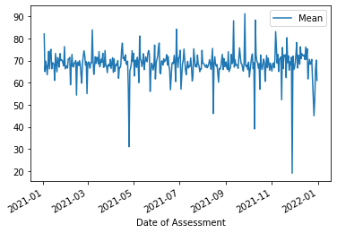

```python
#Glasglow does not really show a trend.
glasgow.plot(x='Date of Assessment', y='Mean')
```

```python
edinburgh = town_env_date[town_env_date['POST_TOWN']=='edinburgh']
edinburgh
```

|  | POST_TOWN | Date of Assessment | Mean |
| --- | --- | --- | --- |
| 12489 | edinburgh | 2021-01-01 | 51.000000 |
| 12490 | edinburgh | 2021-02-01 | 70.355932 |
| 12491 | edinburgh | 2021-03-01 | 72.357143 |
| 12492 | edinburgh | 2021-04-01 | 73.457447 |
| 12493 | edinburgh | 2021-05-01 | 59.800000 |
| ... | ... | ... | ... |
| 12829 | edinburgh | 2021-05-31 | 70.320000 |
| 12830 | edinburgh | 2021-07-31 | 84.666667 |
| 12831 | edinburgh | 2021-08-31 | 72.105882 |
| 12832 | edinburgh | 2021-10-31 | 94.000000 |
| 12833 | edinburgh | 2021-12-31 | 73.800000 |

345 rows × 3 columns

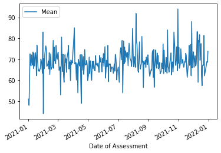

```python
#Edinburgh seems to show larger impact at the end of the year
edinburgh.plot(x='Date of Assessment', y='Mean')
```

```python
aberdeen = town_env_date[town_env_date['POST_TOWN']=='aberdeen']
aberdeen
```

|  | POST_TOWN | Date of Assessment | Mean |
| --- | --- | --- | --- |
| 0 | aberdeen | 2021-02-01 | 64.818182 |
| 1 | aberdeen | 2021-03-01 | 70.153846 |
| 2 | aberdeen | 2021-04-01 | 69.333333 |
| 3 | aberdeen | 2021-06-01 | 72.755556 |
| 4 | aberdeen | 2021-07-01 | 68.844444 |
| ... | ... | ... | ... |
| 290 | aberdeen | 2021-11-30 | 64.500000 |
| 291 | aberdeen | 2021-12-30 | 56.000000 |
| 292 | aberdeen | 2021-03-31 | 71.645161 |
| 293 | aberdeen | 2021-05-31 | 69.794118 |
| 294 | aberdeen | 2021-08-31 | 64.969697 |

295 rows × 3 columns

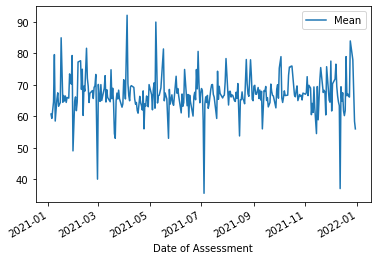

```python
#There does not seem to be a pattern for Aberdeen.
aberdeen.plot(x='Date of Assessment', y='Mean')
```

## 4 Rank Towns by potential environmental impact rating 'Potential Environmental Impact Rating'

```python
town_pot_env = dataset.groupby(['POST_TOWN'])['Potential Environmental Impact Rating'].mean().reset_index(name='Mean')
town_pot_env = town_pot_env.sort_values(by='Mean', ascending=False).reset_index(drop=True)
town_pot_env.head()
```

|  | POST_TOWN | Mean |
| --- | --- | --- |
| 0 | west plean | 126.0 |
| 1 | meigle | 122.0 |
| 2 | comrie | 121.0 |
| 3 | gartocharn | 117.0 |
| 4 | sanday | 117.0 |

## 5 Rank Towns by Current Emissions (T.CO2/yr)

```python
town_curr_em = dataset.groupby(['POST_TOWN'])['Current Emissions (T.CO2/yr)'].mean().reset_index(name='Mean')
town_curr_em = town_pot_env.sort_values(by='Mean', ascending=False).reset_index(drop=True)
town_curr_em.head()
```

|  | POST_TOWN | Mean |
| --- | --- | --- |
| 0 | west plean | 126.0 |
| 1 | meigle | 122.0 |
| 2 | comrie | 121.0 |
| 3 | sanday | 117.0 |
| 4 | gartocharn | 117.0 |

```python
dataset.columns
```

```
Index(['Property_UPRN', 'Postcode', 'POST_TOWN', 'Date of Assessment',
       'Primary Energy Indicator (kWh/m²/year)', 'Total floor area (m²)',
       'Current energy efficiency rating',
       'Current energy efficiency rating band',
       'Potential Energy Efficiency Rating',
       'Potential energy efficiency rating band',
       'Current Environmental Impact Rating',
       'Current Environmental Impact Rating Band',
       'Potential Environmental Impact Rating',
       'Potential Environmental Impact Rating Band',
       'CO2 Emissions Current Per Floor Area (kg.CO2/m²/yr)',
       'WALL_DESCRIPTION', 'WALL_ENERGY_EFF', 'ROOF_DESCRIPTION',
       'ROOF_ENERGY_EFF', 'FLOOR_DESCRIPTION', 'FLOOR_ENERGY_EFF',
       'FLOOR_ENV_EFF', 'WINDOWS_DESCRIPTION', 'WINDOWS_ENERGY_EFF',
       'WINDOWS_ENV_EFF', 'MAINHEAT_DESCRIPTION', 'MAINHEAT_ENERGY_EFF',
       'MAINHEAT_ENV_EFF', 'MAINHEATCONT_DESCRIPTION', 'MAINHEATC_ENERGY_EFF',
       'MAINHEATC_ENV_EFF', 'HOT_WATER_ENERGY_EFF', 'HOT_WATER_ENV_EFF',
       'LIGHTING_DESCRIPTION', 'LIGHTING_ENERGY_EFF', 'LIGHTING_ENV_EFF',
       'Current Emissions (T.CO2/yr)',
       'Potential Reduction in Emissions (T.CO2/yr)',
       'Total current energy costs over 3 years (£)',
       'Current heating costs over 3 years (£)',
       'Potential heating costs over 3 years (£)',
       'Current hot water costs over 3 years (£)',
       'Potential hot water costs over 3 years (£)',
       'Current lighting costs over 3 years (£)',
       'Potential lighting costs over 3 years (£)',
       'Part 1 Construction Age Band', 'Built Form', 'Property Type'],
      dtype='object')
```

## 6 Rank Towns by Potential Reduction in Emissions (T.CO2/yr)

```python
town_pot_red_em = dataset.groupby(['POST_TOWN'])['Potential Reduction in Emissions (T.CO2/yr)'].mean().reset_index(name='Mean')
town_pot_red_em = town_pot_env.sort_values(by='Mean', ascending=False).reset_index(drop=True)
town_pot_red_em.head()
```

|  | POST_TOWN | Mean |
| --- | --- | --- |
| 0 | west plean | 126.0 |
| 1 | meigle | 122.0 |
| 2 | comrie | 121.0 |
| 3 | sanday | 117.0 |
| 4 | gartocharn | 117.0 |

## 7 Rank Towns by potential savings in heating costs (£) over three years

```python
dataset['heat_savings'] = dataset['Current heating costs over 3 years (£)'] - dataset['Potential heating costs over 3 years (£)']
```

```python
town_save_heating = dataset.groupby(['POST_TOWN'])['heat_savings'].mean().reset_index(name='Mean')
town_save_heating = town_save_heating.sort_values(by='Mean', ascending=False).reset_index(drop=True)
town_save_heating.head()
```

|  | POST_TOWN | Mean |
| --- | --- | --- |
| 0 | bonawe | 11085.0 |
| 1 | east dunbartonshire | 11016.0 |
| 2 | morvern | 7098.0 |
| 3 | corsock | 6639.0 |
| 4 | findhorn | 5922.0 |

## 8 Rank Towns by potential savings in hot water costs (£) over three years

```python
dataset['hot_water_save'] = dataset['Current hot water costs over 3 years (£)'] - dataset['Potential hot water costs over 3 years (£)']
town_hot_water_save = dataset.groupby(['POST_TOWN'])['hot_water_save'].mean().reset_index(name='Mean')
town_hot_water_save = town_hot_water_save.sort_values(by='Mean', ascending=False).reset_index(drop=True)
town_hot_water_save.head()
```

|  | POST_TOWN | Mean |
| --- | --- | --- |
| 0 | kincardine | 2283.0 |
| 1 | east dunbartonshire | 1653.0 |
| 2 | by maybole | 1080.0 |
| 3 | corsock | 1056.0 |
| 4 | burghead | 978.0 |

## 9 Rank the top 5 wall descriptions (wall materials) by CO2 emissions current per floor area and wall energy efficiency

## (create a single rating combining CO2 emissions and wall energy efficiency)

```python
dataset['WALL_ENERGY_EFF'].value_counts()
```

```
Good                               33397
Very Good                          26451
Average                            19903
Poor                               18015
Poor | Poor                         9256
                                   ...
Good | Very Poor | Average             1
Very Good | Poor | Average             1
Poor | Average | Poor | Good           1
Very Poor | Average | Very Good        1
Very Good | Good | Average             1
Name: WALL_ENERGY_EFF, Length: 261, dtype: int64
```

```python
#working this off in Excel
#The idea is to average the readings separate by pipes with a lookup table.
wall_energy_eff = dataset['WALL_ENERGY_EFF'].reset_index(drop=True)
wall_energy_eff.to_csv('wall_energy_eff')
```

```python
wall_ee = pd.read_csv('wall_energy_eff.csv')
```

```python
wall_ee.columns
```

```
Index(['index', 'rating a ', ' rating b ', ' rating c ', ' rating d ',
       'rating a_num', 'rating b_num', 'rating c_num', 'rating d_num',
       'valid_cells', 'Value', 'Average_rating', 'Unnamed: 12', 'Rating',
       'Score'],
      dtype='object')
```

```python
dataset['AGG_RATING'] = wall_ee['Average_rating']
```

This is the first time, for subsequent runs, should replace this EE_PRODUCT with WALL_EE_PRODUCT as there is a roof version later on

```python
#creating the emissions-energy efficency (EE) product
dataset['EE_PRODUCT'] = dataset['CO2 Emissions Current Per Floor Area (kg.CO2/m²/yr)'] * dataset['AGG_RATING']
```

```python
dataset['WALL_DESCRIPTION'].value_counts()
```

```
Cavity wall, filled cavity                                                                                                                                     21917
Timber frame, as built, insulated (assumed)                                                                                                                    18387
Cavity wall, as built, no insulation (assumed)                                                                                                                 10100
Sandstone or limestone, as built, no insulation (assumed) | Solid brick, as built, no insulation (assumed)                                                      7881
Cavity wall, as built, insulated (assumed)                                                                                                                      7836
                                                                                                                                                               ...
Granite or whinstone, as built, insulated (assumed) | Sandstone or limestone, as built, no insulation (assumed)                                                    1
Solid brick, as built, no insulation (assumed) | Sandstone or limestone, with internal insulation                                                                  1
Granite or whinstone, as built, no insulation (assumed) | Solid brick, as built, insulated (assumed) | System built, as built, partial insulation (assumed)        1
Cavity wall, filled cavity | Granite or whinstone, as built, insulated (assumed)                                                                                   1
Cavity wall, with internal insulation | Granite or whinstone, with internal insulation | Timber frame, as built, insulated (assumed)                               1
Name: WALL_DESCRIPTION, Length: 1519, dtype: int64
```

```python
#Outcome - the relationship between wall descriptions and the emissions-energy efficency (EE) product
wall_desc_ee = dataset.groupby(['WALL_DESCRIPTION'])['EE_PRODUCT'].mean().reset_index(name='Mean')
wall_desc_ee = wall_desc_ee.sort_values(by='Mean', ascending=True).reset_index(drop=True)
wall_desc_ee
```

|  | WALL_DESCRIPTION | Mean |
| --- | --- | --- |
| 0 | Average thermal transmittance 0.09 W/m²K | -12.500000 |
| 1 | Average thermal transmittance 0.14 W/mÂ²K | 15.000000 |
| 2 | Cavity wall, filled cavity \| Granite or whinst... | 22.000000 |
| 3 | Granite or whinstone, as built, insulated (ass... | 27.000000 |
| 4 | Cavity wall, with internal insulation \| Timber... | 31.500000 |
| ... | ... | ... |
| 1514 | Granite or whinstone, as built, no insulation ... | 744.000000 |
| 1515 | Granite or whinstone, as built, no insulation ... | 806.000000 |
| 1516 | Cavity wall, as built, partial insulation (ass... | 832.000000 |
| 1517 | Timber frame, as built, no insulation (assumed... | 895.500000 |
| 1518 | Granite or whinstone, as built, no insulation ... | 957.666667 |

1519 rows × 2 columns

## 10 Rank the top 5 roof descriptions by CO2 emissions current per floor area and wall energy efficiency

## (create a single rating combining CO2 emissions and wall energy efficiency)

```python
dataset['ROOF_ENERGY_EFF'].value_counts()
```

```
Good                                40333
Very Good                           26581
N/A                                 11929
Good                                11390
Very Poor                            7909
                                    ...
N/A | Poor | Good                       1
N/A | Very Good | Very Poor             1
Very Poor | Average | Very Good         1
Average | Very Poor | Average           1
Average | Poor | Very Good              1
Name: ROOF_ENERGY_EFF, Length: 294, dtype: int64
```

```python
#export to work off separately in Excel
#vlookup to convert the strings into values, and then to create an average value
roof_energy_eff = dataset['ROOF_ENERGY_EFF'].to_csv('roof_ee.csv')
```

```python
roof_ee = pd.read_csv('roof_ee_new.csv')
```

```python
roof_ee.head()
```

|  | Index | rating_a | rating_b | rating_c | rating_a_num | rating_b_num | rating_c_num | valid_cells | value | average_rating | Unnamed: 10 | Unnamed: 11 | Unnamed: 12 | Unnamed: 13 | Unnamed: 14 | Unnamed: 15 | Unnamed: 16 | Value | Score |
| --- | --- | --- | --- | --- | --- | --- | --- | --- | --- | --- | --- | --- | --- | --- | --- | --- | --- | --- | --- |
| 0 | 0 | Poor | NaN | NaN | 4.0 | NaN | NaN | 1 | 4 | 4 | NaN | NaN | NaN | NaN | NaN | NaN | NaN | VeryGood | 1.0 |
| 1 | 1 | Average | Good | VeryPoor | 3.0 | 3.0 | 5.0 | 3 | 11 | 3.666666667 | NaN | NaN | NaN | NaN | NaN | NaN | NaN | Good | 2.0 |
| 2 | 2 |  | NaN | NaN | NaN | NaN | NaN | 0 | 0 | #DIV/0! | NaN | NaN | NaN | NaN | NaN | NaN | NaN | Average | 3.0 |
| 3 | 3 | Good | NaN | NaN | 3.0 | NaN | NaN | 1 | 3 | 3 | NaN | NaN | NaN | NaN | NaN | NaN | NaN | Poor | 4.0 |
| 4 | 4 | Good | NaN | NaN | 3.0 | NaN | NaN | 1 | 3 | 3 | NaN | NaN | NaN | NaN | NaN | NaN | NaN | VeryPoor | 5.0 |

```python
roof_ee['average_rating'].replace('#DIV/0!',value=-1)
```

```
0                   4
1         3.666666667
2                  -1
3                   3
4                   3
             ...
185034              4
185035              3
185036              3
185037             -1
185038             -1
Name: average_rating, Length: 185039, dtype: object
```

```python
dataset['ROOF_RATING'] = roof_ee['average_rating']
```

```python
dataset['ROOF_RATING'] = dataset['ROOF_RATING'].replace('#DIV/0!',value=-1)
```

```python
dataset['ROOF_RATING'] = dataset['ROOF_RATING'].astype(float)
```

```python
dataset['ROOF_EE_PRODUCT'] = dataset['CO2 Emissions Current Per Floor Area (kg.CO2/m²/yr)'] * dataset['ROOF_RATING']
```

```python
roof_desc = dataset.groupby(['ROOF_DESCRIPTION'])['ROOF_EE_PRODUCT'].mean().reset_index(name='Mean')
roof_desc = roof_desc.sort_values(by='Mean', ascending=True).reset_index(drop=True)
roof_desc

#ignore the initial negative numbers, as they really mean negative numbers
```

|  | ROOF_DESCRIPTION | Mean |
| --- | --- | --- |
| 0 | (another dwelling above) \| Pitched, 100 mm lof... | -61.892857 |
| 1 | (another dwelling above) \| Pitched, 100 mm lof... | -51.000000 |
| 2 | (another dwelling above) | -42.876719 |
| 3 | (another dwelling above) | -42.743910 |
| 4 | (another dwelling above) \| Pitched, 75 mm loft... | -37.000000 |
| ... | ... | ... |
| 1979 | Pitched, 25 mm loft insulation \| Pitched, 50 m... | 853.666667 |
| 1980 | Pitched, limited insulation (assumed) \| Pitche... | 868.000000 |
| 1981 | Pitched, 250 mm loft insulation \| Pitched, ins... | 883.666667 |
| 1982 | Roof room(s), ceiling insulated \| Pitched, 100... | 905.000000 |
| 1983 | Pitched, 50 mm loft insulation \| Pitched, no i... | 1190.000000 |

1984 rows × 2 columns

```python
roof_desc[9:15]
```

|  | ROOF_DESCRIPTION | Mean |
| --- | --- | --- |
| 9 | (another dwelling above) \| Pitched, insulated ... | 8.200000 |
| 10 | Flat, no insulation (assumed) \| Pitched, 300 m... | 12.000000 |
| 11 | Pitched, 400 mm loft insulation \| Roof room(s)... | 14.000000 |
| 12 | Flat, insulated (assumed) \| Pitched, 400 mm lo... | 23.333333 |
| 13 | Pitched, 200 mm loft insulation \| Pitched, 400... | 23.333333 |
| 14 | (another dwelling above) \| Flat, insulated (as... | 27.745098 |

# Part 2: Algorithm Challenges

## Algorithm Challenge 1: Build and algorithm to find correlations between CO2 emissions current per floor area vs wall description and wall energy efficiency

```python
#The same groupby dataframe from Part 1 Challenge 9 because the same indicators are used.
wall_desc = dataset['WALL_DESCRIPTION']
```

```python
#implementation from https://www.toptal.com/python/topic-modeling-python
#using LDA to create topic models from the wall descriptions

from sklearn.feature_extraction.text import CountVectorizer
from sklearn.feature_extraction.text import TfidfTransformer
from sklearn.decomposition import LatentDirichletAllocation as LDA
from nltk.corpus import stopwords
```

```python
#approach from https://www.toptal.com/python/topic-modeling-python

corpus = wall_desc_ee['WALL_DESCRIPTION']
```

```python
import nltk
nltk.download('stopwords')
```

```
True
```

```python
count_vect = CountVectorizer(stop_words=stopwords.words('english'), lowercase=True)
x_counts = count_vect.fit_transform(corpus)
x_counts.todense()
```

```
matrix([[0, 0, 0, ..., 1, 0, 0],
        [0, 0, 0, ..., 1, 0, 0],
        [0, 0, 0, ..., 0, 1, 1],
        ...,
        [0, 0, 0, ..., 0, 1, 0],
        [0, 0, 0, ..., 0, 0, 0],
        [0, 0, 0, ..., 0, 0, 1]], dtype=int64)
```

```python
count_vect.get_feature_names()
```

```
['00',
 '06',
 '07',
 '09',
 '10',
 '11',
 '12',
 '13',
 '14',
 '15',
 '16',
 '17',
 '18',
 '19',
 '20',
 '21',
 '22',
 '23',
 '24',
 '25',
 '26',
 '27',
 '28',
 '29',
 '30',
 '31',
 '33',
 '35',
 '36',
 '38',
 '40',
 '41',
 '42',
 '43',
 '45',
 '46',
 '47',
 '48',
 '51',
 '52',
```

[output cut: 41 more lines]

```
 'insulation',
 'internal',
 'limestone',
 'm²k',
 'mâ²k',
 'park',
 'partial',
 'sandstone',
 'solid',
 'system',
 'thermal',
 'timber',
 'transmittance',
 'wall',
 'whinstone']
```

```python
tfidf_transformer = TfidfTransformer()
x_tfidf = tfidf_transformer.fit_transform(x_counts)
```

```python
dimension = 10
lda = LDA(n_components = dimension)
lda_array = lda.fit_transform(x_tfidf)
lda_array
```

```
array([[0.03223826, 0.03223826, 0.03223826, ..., 0.03223826, 0.03223826,
        0.03225258],
       [0.03174458, 0.03174458, 0.03174458, ..., 0.03174458, 0.03174458,
        0.71429315],
       [0.02348672, 0.02350661, 0.02348661, ..., 0.42116729, 0.39092268,
        0.02348093],
       ...,
       [0.45022049, 0.35132919, 0.02480839, ..., 0.02481099, 0.02480709,
        0.0248011 ],
       [0.42360646, 0.35654825, 0.02748175, ..., 0.02748015, 0.02748168,
        0.02747578],
       [0.0269932 , 0.02701616, 0.02700624, ..., 0.02699273, 0.7570274 ,
        0.02698739]])
```

```python
components = [lda.components_[i] for i in range(len(lda.components_))]
features = count_vect.get_feature_names()
important_words = [sorted(features, key = lambda x: components[j][features.index(x)], reverse = True)[:3] for j in range(len(components))]
important_words
```

```
[['timber', 'frame', 'built'],
 ['brick', 'solid', 'insulation'],
 ['system', 'built', 'insulation'],
 ['additional', 'timber', 'frame'],
 ['transmittance', 'average', 'thermal'],
 ['built', 'assumed', 'whinstone'],
 ['limestone', 'sandstone', 'built'],
 ['cavity', 'wall', 'filled'],
 ['granite', 'whinstone', 'built'],
 ['average', 'thermal', 'transmittance']]
```

```python
lda_array.shape
```

```
(1519, 10)
```

```python
important_words[6]
```

```
['limestone', 'sandstone', 'built']
```

```python
list_max_wall_ee = []

for i in range(len(lda_array)):
    list_array = list(lda_array[i])
    max_num = list_array.index(max(list_array))
    list_max_wall_ee.append(max_num)

print(len(list_max_wall_ee))
```

```
1519
```

```python
wall_desc_ee['description_number'] = list_max_wall_ee
```

```python
wall_desc_ee.head(10)
```

|  | WALL_DESCRIPTION | Mean | description_number |
| --- | --- | --- | --- |
| 0 | Average thermal transmittance 0.09 W/m²K | -12.5 | 4 |
| 1 | Average thermal transmittance 0.14 W/mÂ²K | 15.0 | 9 |
| 2 | Cavity wall, filled cavity \| Granite or whinst... | 22.0 | 7 |
| 3 | Granite or whinstone, as built, insulated (ass... | 27.0 | 8 |
| 4 | Cavity wall, with internal insulation \| Timber... | 31.5 | 3 |
| 5 | Average thermal transmittance 0.18 W/m?K | 35.0 | 9 |
| 6 | Granite or whinstone, as built, partial insula... | 36.0 | 1 |
| 7 | Average thermal transmittance 0.13 W/m?K | 40.0 | 9 |
| 8 | Average thermal transmittance 0.15 W/m?K | 40.0 | 9 |
| 9 | Average thermal transmittance 0.43 W/m²K | 43.5 | 9 |

```python
wall_desc_ee.dtypes
```

```
WALL_DESCRIPTION       object
Mean                  float64
description_number      int64
dtype: object
```

```python
wall_ee_short_des = []

for i in range(len(wall_desc_ee)):
    number = wall_desc_ee['description_number'][i]
    description = important_words[number]
    wall_ee_short_des.append(description)

print(len(wall_ee_short_des))
```

```
1519
```

```python
wall_desc_ee["short_description"] = wall_ee_short_des
```

```python
wall_desc_ee.head(10)
```

|  | WALL_DESCRIPTION | Mean | description_number | short_description |
| --- | --- | --- | --- | --- |
| 0 | Average thermal transmittance 0.09 W/m²K | -12.5 | 4 | [transmittance, average, thermal] |
| 1 | Average thermal transmittance 0.14 W/mÂ²K | 15.0 | 9 | [average, thermal, transmittance] |
| 2 | Cavity wall, filled cavity \| Granite or whinst... | 22.0 | 7 | [cavity, wall, filled] |
| 3 | Granite or whinstone, as built, insulated (ass... | 27.0 | 8 | [granite, whinstone, built] |
| 4 | Cavity wall, with internal insulation \| Timber... | 31.5 | 3 | [additional, timber, frame] |
| 5 | Average thermal transmittance 0.18 W/m?K | 35.0 | 9 | [average, thermal, transmittance] |
| 6 | Granite or whinstone, as built, partial insula... | 36.0 | 1 | [brick, solid, insulation] |
| 7 | Average thermal transmittance 0.13 W/m?K | 40.0 | 9 | [average, thermal, transmittance] |
| 8 | Average thermal transmittance 0.15 W/m?K | 40.0 | 9 | [average, thermal, transmittance] |
| 9 | Average thermal transmittance 0.43 W/m²K | 43.5 | 9 | [average, thermal, transmittance] |

```python
description_corr = wall_desc_ee.groupby(['description_number'])['Mean'].mean().reset_index(name='agg_mean')
description_corr.sort_values(by='agg_mean')
```

|  | description_number | agg_mean |
| --- | --- | --- |
| 4 | 4 | 85.527030 |
| 9 | 9 | 89.122080 |
| 7 | 7 | 171.748836 |
| 3 | 3 | 179.854958 |
| 1 | 1 | 191.418012 |
| 2 | 2 | 205.477818 |
| 6 | 6 | 215.009181 |
| 0 | 0 | 232.060242 |
| 5 | 5 | 241.089506 |
| 8 | 8 | 255.058597 |

```python
agg_wall_short_desc = []

for i in range(len(description_corr)):
    number = description_corr['description_number'][i]
    description = important_words[number]
    agg_wall_short_desc.append(description)

print(len(agg_wall_short_desc))
```

```
10
```

```python
description_corr['short_desc'] = agg_wall_short_desc
```

```python
description_corr
```

|  | description_number | agg_mean | short_desc |
| --- | --- | --- | --- |
| 0 | 0 | 232.060242 | [timber, frame, built] |
| 1 | 1 | 191.418012 | [brick, solid, insulation] |
| 2 | 2 | 205.477818 | [system, built, insulation] |
| 3 | 3 | 179.854958 | [additional, timber, frame] |
| 4 | 4 | 85.527030 | [transmittance, average, thermal] |
| 5 | 5 | 241.089506 | [built, assumed, whinstone] |
| 6 | 6 | 215.009181 | [limestone, sandstone, built] |
| 7 | 7 | 171.748836 | [cavity, wall, filled] |
| 8 | 8 | 255.058597 | [granite, whinstone, built] |
| 9 | 9 | 89.122080 | [average, thermal, transmittance] |

```python
description_corr = description_corr.sort_values(by='agg_mean', ascending=True).reset_index(drop=True)
description_corr
```

|  | description_number | agg_mean | short_desc |
| --- | --- | --- | --- |
| 0 | 4 | 85.527030 | [transmittance, average, thermal] |
| 1 | 9 | 89.122080 | [average, thermal, transmittance] |
| 2 | 7 | 171.748836 | [cavity, wall, filled] |
| 3 | 3 | 179.854958 | [additional, timber, frame] |
| 4 | 1 | 191.418012 | [brick, solid, insulation] |
| 5 | 2 | 205.477818 | [system, built, insulation] |
| 6 | 6 | 215.009181 | [limestone, sandstone, built] |
| 7 | 0 | 232.060242 | [timber, frame, built] |
| 8 | 5 | 241.089506 | [built, assumed, whinstone] |
| 9 | 8 | 255.058597 | [granite, whinstone, built] |

## Algorithm Challenge 2: Build and algorithm to find correlations between CO2 emissions current per floor area vs roof description and roof energy efficiency

```python
#do the same topic model for roof descriptions
#Starting on Part 2 Challenge 2. The indicator from Part 1 #10 is used as they are the same.
roof_corpus = roof_desc['ROOF_DESCRIPTION']
```

```python
roof_count_vect = CountVectorizer(stop_words=stopwords.words('english'), lowercase=True)
roof_counts = roof_count_vect.fit_transform(roof_corpus)
roof_counts.todense()
```

```
matrix([[0, 0, 0, ..., 0, 0, 0],
        [0, 0, 0, ..., 0, 0, 0],
        [0, 0, 0, ..., 0, 0, 0],
        ...,
        [0, 0, 0, ..., 0, 0, 0],
        [0, 0, 0, ..., 0, 0, 0],
        [0, 0, 0, ..., 0, 0, 0]], dtype=int64)
```

```python
roof_count_vect.get_feature_names()
```

```
['05',
 '06',
 '07',
 '08',
 '09',
 '10',
 '100',
 '11',
 '12',
 '13',
 '14',
 '15',
 '150',
 '16',
 '17',
 '18',
 '19',
 '20',
 '200',
 '21',
 '22',
 '23',
 '24',
 '25',
 '250',
 '270',
 '29',
 '300',
 '31',
 '32',
 '35',
 '350',
 '38',
 '40',
 '400',
 '50',
 '57',
 '75',
 '81',
 'additional',
```

[output cut: 9 more lines]

```
 'insulation',
 'invalid',
 'limited',
 'loft',
 'mm',
 'm²k',
 'mâ²k',
 'pitched',
 'premises',
 'rafters',
 'roof',
 'room',
 'thatched',
 'thermal',
 'transmittance']
```

```python
tfidf_transformer = TfidfTransformer()
roof_tfidf = tfidf_transformer.fit_transform(roof_counts)
```

```python
dimension = 10
roof_lda = LDA(n_components = dimension)
roof_lda_array = roof_lda.fit_transform(roof_tfidf)
roof_lda_array
```

```
array([[0.03008411, 0.03008561, 0.03007957, ..., 0.03007827, 0.49806048,
        0.03008409],
       [0.03008411, 0.03008561, 0.03007957, ..., 0.03007827, 0.49806048,
        0.03008409],
       [0.04142136, 0.04142136, 0.04142136, ..., 0.04142136, 0.62720779,
        0.04142136],
       ...,
       [0.02784578, 0.02784552, 0.27840889, ..., 0.02783814, 0.0278427 ,
        0.02784572],
       [0.02506655, 0.02506658, 0.31475361, ..., 0.02505973, 0.02506373,
        0.02506699],
       [0.02793866, 0.74856102, 0.02793915, ..., 0.02793059, 0.02793528,
        0.02793882]])
```

```python
print(len(roof_lda_array))
```

```
1984
```

```python
roof_components = [roof_lda.components_[i] for i in range(len(roof_lda.components_))]
roof_features = roof_count_vect.get_feature_names()
```

```python
roof_features
```

```
['05',
 '06',
 '07',
 '08',
 '09',
 '10',
 '100',
 '11',
 '12',
 '13',
 '14',
 '15',
 '150',
 '16',
 '17',
 '18',
 '19',
 '20',
 '200',
 '21',
 '22',
 '23',
 '24',
 '25',
 '250',
 '270',
 '29',
 '300',
 '31',
 '32',
 '35',
 '350',
 '38',
 '40',
 '400',
 '50',
 '57',
 '75',
 '81',
 'additional',
```

[output cut: 9 more lines]

```
 'insulation',
 'invalid',
 'limited',
 'loft',
 'mm',
 'm²k',
 'mâ²k',
 'pitched',
 'premises',
 'rafters',
 'roof',
 'room',
 'thatched',
 'thermal',
 'transmittance']
```

```python
len(roof_features)
```

```
64
```

```python
len(roof_components)
```

```
10
```

```python
roof_important_words = [sorted(roof_features, key = lambda x: roof_components[j][roof_features.index(x)], reverse = True)[:3] for j in range(len(roof_components))]
roof_important_words
```

```
[['200', 'insulation', 'pitched'],
 ['insulation', 'pitched', 'loft'],
 ['insulated', 'ceiling', 'room'],
 ['300', 'insulation', 'pitched'],
 ['assumed', 'insulation', 'limited'],
 ['270', 'insulation', 'pitched'],
 ['insulation', 'pitched', 'mm'],
 ['average', 'thermal', 'transmittance'],
 ['another', 'dwelling', '350'],
 ['150', 'insulation', 'pitched']]
```

```python
list_max_roof_ee = []

for i in range(len(roof_lda_array)):
    list_array = list(roof_lda_array[i])
    max_num = list_array.index(max(list_array))
    list_max_roof_ee.append(max_num)

print(len(list_max_roof_ee))
```

```
1984
```

```python
roof_desc['desc_num'] = list_max_roof_ee
```

```python
roof_description_corr = roof_desc.groupby(['desc_num'])['Mean'].mean().reset_index(name='agg_mean')
roof_description_corr = roof_description_corr.sort_values(by='agg_mean')
roof_description_corr
```

|  | desc_num | agg_mean |
| --- | --- | --- |
| 7 | 7 | 73.692240 |
| 8 | 8 | 209.731351 |
| 5 | 5 | 215.616475 |
| 2 | 2 | 219.568682 |
| 9 | 9 | 224.539906 |
| 0 | 0 | 226.094061 |
| 3 | 3 | 229.226621 |
| 1 | 1 | 239.012800 |
| 6 | 6 | 240.832711 |
| 4 | 4 | 286.202318 |

```python
agg_roof_short_desc = []

for i in range(len(roof_description_corr)):
    number = roof_description_corr['desc_num'][i]
    description = roof_important_words[number]
    agg_roof_short_desc.append(description)

print(len(agg_roof_short_desc))
```

```
10
```

```python
roof_description_corr['short_desc'] = agg_roof_short_desc
```

```python
#Outcome of Algorithm Challenge 2: There is some relationship between the descriptions and the roof energy efficiency and emissions (the lower the figure, the better the energy performance)
roof_description_corr
```

|  | desc_num | agg_mean | short_desc |
| --- | --- | --- | --- |
| 7 | 7 | 73.692240 | [200, insulation, pitched] |
| 8 | 8 | 209.731351 | [insulation, pitched, loft] |
| 5 | 5 | 215.616475 | [insulated, ceiling, room] |
| 2 | 2 | 219.568682 | [300, insulation, pitched] |
| 9 | 9 | 224.539906 | [assumed, insulation, limited] |
| 0 | 0 | 226.094061 | [270, insulation, pitched] |
| 3 | 3 | 229.226621 | [insulation, pitched, mm] |
| 1 | 1 | 239.012800 | [average, thermal, transmittance] |
| 6 | 6 | 240.832711 | [another, dwelling, 350] |
| 4 | 4 | 286.202318 | [150, insulation, pitched] |

## Algorithm Challenge 3: Build and algorithm to find correlations between construction age band vs current energy efficiency and current emissions (T.CO2/yr)

The approach to this is to create a linear regression model using the age of the building and to find out the relationship between current energy efficiency and current emissions.

```python
dataset.columns
```

```
Index(['Property_UPRN', 'Postcode', 'POST_TOWN', 'Date of Assessment',
       'Primary Energy Indicator (kWh/m²/year)', 'Total floor area (m²)',
       'Current energy efficiency rating',
       'Current energy efficiency rating band',
       'Potential Energy Efficiency Rating',
       'Potential energy efficiency rating band',
       'Current Environmental Impact Rating',
       'Current Environmental Impact Rating Band',
       'Potential Environmental Impact Rating',
       'Potential Environmental Impact Rating Band',
       'CO2 Emissions Current Per Floor Area (kg.CO2/m²/yr)',
       'WALL_DESCRIPTION', 'WALL_ENERGY_EFF', 'ROOF_DESCRIPTION',
       'ROOF_ENERGY_EFF', 'FLOOR_DESCRIPTION', 'FLOOR_ENERGY_EFF',
       'FLOOR_ENV_EFF', 'WINDOWS_DESCRIPTION', 'WINDOWS_ENERGY_EFF',
       'WINDOWS_ENV_EFF', 'MAINHEAT_DESCRIPTION', 'MAINHEAT_ENERGY_EFF',
       'MAINHEAT_ENV_EFF', 'MAINHEATCONT_DESCRIPTION', 'MAINHEATC_ENERGY_EFF',
       'MAINHEATC_ENV_EFF', 'HOT_WATER_ENERGY_EFF', 'HOT_WATER_ENV_EFF',
       'LIGHTING_DESCRIPTION', 'LIGHTING_ENERGY_EFF', 'LIGHTING_ENV_EFF',
       'Current Emissions (T.CO2/yr)',
       'Potential Reduction in Emissions (T.CO2/yr)',
       'Total current energy costs over 3 years (£)',
       'Current heating costs over 3 years (£)',
       'Potential heating costs over 3 years (£)',
       'Current hot water costs over 3 years (£)',
       'Potential hot water costs over 3 years (£)',
       'Current lighting costs over 3 years (£)',
       'Potential lighting costs over 3 years (£)',
       'Part 1 Construction Age Band', 'Built Form', 'Property Type',
       'heat_savings', 'hot_water_save', 'AGG_RATING', 'EE_PRODUCT',
       'ROOF_RATING', 'ROOF_EE_PRODUCT'],
      dtype='object')
```

```python
age_of_build = dataset.groupby(['Part 1 Construction Age Band'])['Current energy efficiency rating','Current Emissions (T.CO2/yr)'].mean().reset_index()
```

```python
age_of_build.head
```

```
<bound method NDFrame.head of    Part 1 Construction Age Band  Current energy efficiency rating  \
0                     1919-1929                         62.244228
1                     1930-1949                         64.988258
2                     1950-1964                         65.663387
3                     1965-1975                         66.230327
4                     1976-1983                         67.528634
5                     1984-1991                         69.085491
6                     1992-1998                         71.311040
7                     1999-2002                         72.708708
8                     2003-2007                         76.565927
9                  2008 onwards                         78.443133
10                  before 1919                         59.158740

    Current Emissions (T.CO2/yr)
0                       4.805747
1                       4.264428
2                       3.973697
3                       4.079704
4                       3.858721
5                       3.484475
6                       3.473204
7                       3.404447
8                       2.898558
9                       2.598642
10                      5.644251  >
```

```python
age_of_build['Year'] = [1924, 1940, 1957, 1970, 1979, 1987, 1995, 2000, 2005, 2015, 1919]
```

```python
age_of_build = age_of_build.sort_values(by='Year', ascending=True).reset_index(drop=True)
age_of_build
```

|  | Part 1 Construction Age Band | Current energy efficiency rating | Current Emissions (T.CO2/yr) | Year |
| --- | --- | --- | --- | --- |
| 0 | before 1919 | 59.158740 | 5.644251 | 1919 |
| 1 | 1919-1929 | 62.244228 | 4.805747 | 1924 |
| 2 | 1930-1949 | 64.988258 | 4.264428 | 1940 |
| 3 | 1950-1964 | 65.663387 | 3.973697 | 1957 |
| 4 | 1965-1975 | 66.230327 | 4.079704 | 1970 |
| 5 | 1976-1983 | 67.528634 | 3.858721 | 1979 |
| 6 | 1984-1991 | 69.085491 | 3.484475 | 1987 |
| 7 | 1992-1998 | 71.311040 | 3.473204 | 1995 |
| 8 | 1999-2002 | 72.708708 | 3.404447 | 2000 |
| 9 | 2003-2007 | 76.565927 | 2.898558 | 2005 |
| 10 | 2008 onwards | 78.443133 | 2.598642 | 2015 |

```python
age_of_build['est_building_age'] = 2022-age_of_build['Year']
```

```python
age_of_build
```

|  | Part 1 Construction Age Band | Current energy efficiency rating | Current Emissions (T.CO2/yr) | Year | est_building_age |
| --- | --- | --- | --- | --- | --- |
| 0 | before 1919 | 59.158740 | 5.644251 | 1919 | 103 |
| 1 | 1919-1929 | 62.244228 | 4.805747 | 1924 | 98 |
| 2 | 1930-1949 | 64.988258 | 4.264428 | 1940 | 82 |
| 3 | 1950-1964 | 65.663387 | 3.973697 | 1957 | 65 |
| 4 | 1965-1975 | 66.230327 | 4.079704 | 1970 | 52 |
| 5 | 1976-1983 | 67.528634 | 3.858721 | 1979 | 43 |
| 6 | 1984-1991 | 69.085491 | 3.484475 | 1987 | 35 |
| 7 | 1992-1998 | 71.311040 | 3.473204 | 1995 | 27 |
| 8 | 1999-2002 | 72.708708 | 3.404447 | 2000 | 22 |
| 9 | 2003-2007 | 76.565927 | 2.898558 | 2005 | 17 |
| 10 | 2008 onwards | 78.443133 | 2.598642 | 2015 | 7 |

There is some looseness here, as buildings before 1919 are classified have a 1919 start date.

```python
year_dict = {0:0,"before 1919":1919, "1919-1929":1924, "1930-1949":1940,"1950-1964":1957,"1965-1975":1970, "1976-1983":1979,"1984-1991":1987,"1992-1998":1995,"1999-2002":2000,"2003-2007":2005, "2008 onwards":2015}
```

```python
dataset["Part 1 Construction Age Band"] = dataset["Part 1 Construction Age Band"].fillna(0)
```

```python
all_building_year = []

for i in range(len(dataset)):
    year = year_dict[dataset['Part 1 Construction Age Band'][i]]
    all_building_year.append(year)

print(len(all_building_year))
```

```
185039
```

```python
dataset['est_build_year'] = all_building_year
```

```python
dataset['build_age'] = 2022-dataset['est_build_year']
```

```python
#for analysis, drop rows whhere build_age = 2022

analysis_build_age = dataset[dataset['build_age'] !=2022].reset_index(drop=True)
```

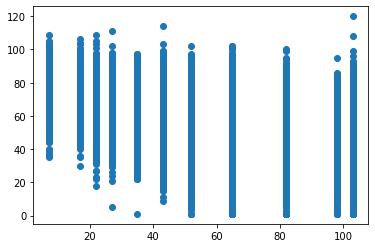

```python
plt.scatter(analysis_build_age['build_age'], analysis_build_age['Current energy efficiency rating'])
plt.show()
```

```python
from sklearn.linear_model import LinearRegression
```

```python
len(analysis_build_age)
```

```
155067
```

```python
0.8*len(analysis_build_age)
```

```
124053.6
```

```python
0.2*len(analysis_build_age)
```

```
31013.4
```

```python
analysis_build_age['build_age']
```

```
0          82
1          98
2          52
3          22
4         103
         ...
155062      7
155063     82
155064     35
155065     52
155066     52
Name: build_age, Length: 155067, dtype: int64
```

```python
import numpy as np

X = np.array(analysis_build_age['build_age'])
y = analysis_build_age['Current energy efficiency rating']
```

```python
X=X.reshape(-1,1)
```

```python
lm = LinearRegression()
lm.fit(X, y)
```

```
LinearRegression()
```

```python
print(lm.coef_)
```

```
[-0.16721293]
```

```python
print(lm.intercept_)
```

```
76.51658142966357
```

```python
#Creating the regression model between building age and current emissions
z = analysis_build_age['Current Emissions (T.CO2/yr)']
```

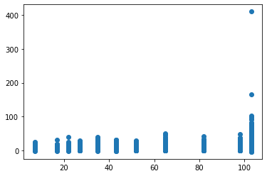

```python
plt.scatter(X, z)
plt.show()
```

```python
lm2 = LinearRegression()
lm2.fit(X, z)
```

```
LinearRegression()
```

```python
print(lm2.coef_)
print(lm2.intercept_)
```

```
[0.0280689]
2.4789921547361917
```

### For energy efficiency, the older the building, energy efficiency (higher the better) declines by 0.167 units. Also, the older the building, the higher the emissions (lower the better), by 0.028 units.

### As expected, the newer the building, the better the energy efficiency; the newer the building, emissions are lower.

## Algorithm Challenge 4 Build an algorithm that takes as input the characteristics of a building (any field of the dataset) and outputs recommendations on the elements of the house to be modified to improve its energy performance - (15 points)

Code from the LDA process (same as 1 and 2) comes from: https://towardsdatascience.com/how-to-easily-cluster-textual-data-in-python-ab27040b07d8

The approach to this would be to instead, look at the best performers in terms of emissions and energy efficiency, and use the wall and roof descriptions to look at what good energy performers will look like.

The LDA approach will be used again to shorten the descriptions.

```python
dataset.dtypes
```

```
Property_UPRN                                          float64
Postcode                                                object
POST_TOWN                                               object
Date of Assessment                                      object
Primary Energy Indicator (kWh/m²/year)                 float64
Total floor area (m²)                                  float64
Current energy efficiency rating                       float64
Current energy efficiency rating band                   object
Potential Energy Efficiency Rating                     float64
Potential energy efficiency rating band                 object
Current Environmental Impact Rating                    float64
Current Environmental Impact Rating Band                object
Potential Environmental Impact Rating                  float64
Potential Environmental Impact Rating Band              object
CO2 Emissions Current Per Floor Area (kg.CO2/m²/yr)    float64
WALL_DESCRIPTION                                        object
WALL_ENERGY_EFF                                         object
ROOF_DESCRIPTION                                        object
ROOF_ENERGY_EFF                                         object
FLOOR_DESCRIPTION                                       object
FLOOR_ENERGY_EFF                                        object
FLOOR_ENV_EFF                                           object
WINDOWS_DESCRIPTION                                     object
WINDOWS_ENERGY_EFF                                      object
WINDOWS_ENV_EFF                                         object
MAINHEAT_DESCRIPTION                                    object
MAINHEAT_ENERGY_EFF                                     object
MAINHEAT_ENV_EFF                                        object
MAINHEATCONT_DESCRIPTION                                object
MAINHEATC_ENERGY_EFF                                    object
MAINHEATC_ENV_EFF                                       object
HOT_WATER_ENERGY_EFF                                    object
HOT_WATER_ENV_EFF                                       object
LIGHTING_DESCRIPTION                                    object
LIGHTING_ENERGY_EFF                                     object
LIGHTING_ENV_EFF                                        object
Current Emissions (T.CO2/yr)                           float64
Potential Reduction in Emissions (T.CO2/yr)            float64
Total current energy costs over 3 years (£)            float64
Current heating costs over 3 years (£)                 float64
Potential heating costs over 3 years (£)               float64
Current hot water costs over 3 years (£)               float64
Potential hot water costs over 3 years (£)             float64
Current lighting costs over 3 years (£)                float64
Potential lighting costs over 3 years (£)              float64
Part 1 Construction Age Band                            object
Built Form                                              object
Property Type                                           object
heat_savings                                           float64
hot_water_save                                         float64
AGG_RATING                                             float64
EE_PRODUCT                                             float64
ROOF_RATING                                            float64
ROOF_EE_PRODUCT                                        float64
est_build_year                                           int64
build_age                                                int64
dtype: object
```

```python
emissions = dataset.sort_values(by="Current Emissions (T.CO2/yr)").reset_index(drop=True)
```

```python
emissions.head(20)
```

|  | Property_UPRN | Postcode | POST_TOWN | Date of Assessment | Primary Energy Indicator (kWh/m²/year) | Total floor area (m²) | Current energy efficiency rating | Current energy efficiency rating band | Potential Energy Efficiency Rating | Potential energy efficiency rating band | ... | Built Form | Property Type | heat_savings | hot_water_save | AGG_RATING | EE_PRODUCT | ROOF_RATING | ROOF_EE_PRODUCT | est_build_year | build_age |
| --- | --- | --- | --- | --- | --- | --- | --- | --- | --- | --- | --- | --- | --- | --- | --- | --- | --- | --- | --- | --- | --- |
| 0 | 1.235876e+09 | PA21 2DB | tighnabruaich | 28/10/2021 | -858.0 | 143.0 | 268.0 | A | 291.0 | A | ... | Detached | House | 0.0 | 159.0 | 5.000000 | -795.0 | 4.0 | -636.0 | 0 | 2022 |
| 1 | 1.235429e+09 | KY2 6FN | kirkcaldy | 11/06/2021 | -145.0 | 346.0 | 141.0 | A | 141.0 | A | ... | Detached | Bungalow | 0.0 | 0.0 | 5.000000 | -125.0 | 4.0 | -100.0 | 0 | 2022 |
| 2 | 1.235052e+09 | EH23 4PS | gorebridge | 06/04/2021 | -60.0 | 215.0 | 124.0 | A | 134.0 | A | ... | Detached | Bungalow | 0.0 | 0.0 | 5.000000 | -135.0 | 4.0 | -108.0 | 0 | 2022 |
| 3 | 1.235755e+09 | EH23 4NN | gorebridge | 08/04/2021 | -60.0 | 215.0 | 124.0 | A | 134.0 | A | ... | Detached | Bungalow | 0.0 | 0.0 | 5.000000 | -135.0 | 4.0 | -108.0 | 0 | 2022 |
| 4 | 1.001273e+09 | KA16 9LJ | newmilns | 29/07/2021 | 140.0 | 199.0 | 78.0 | C | 87.0 | B | ... | Detached | House | 990.0 | 300.0 | 3.000000 | -54.0 | 4.5 | -81.0 | 1919 | 103 |
| 5 | 1.235743e+09 | G71 7FR | glasgow | 23/03/2021 | -263.0 | 75.0 | 143.0 | A | 144.0 | A | ... | Semi-Detached | House | 0.0 | 78.0 | 5.000000 | -219.5 | 4.0 | -175.6 | 0 | 2022 |
| 6 | 1.235888e+09 | PH36 4HY | acharacle | 18/11/2021 | -125.0 | 146.0 | 126.0 | A | 127.0 | A | ... | Detached | House | 0.0 | 267.0 | 5.000000 | -105.0 | 4.0 | -84.0 | 0 | 2022 |
| 7 | 1.234627e+09 | TD11 3NG | duns | 09/11/2021 | 88.0 | 226.0 | 90.0 | B | 102.0 | A | ... | Detached | House | -27.0 | 294.0 | 4.500000 | -58.5 | 3.0 | -39.0 | 1919 | 103 |
| 8 | 1.235783e+09 | G83 8SD | gartocharn | 26/05/2021 | -61.0 | 292.0 | 115.0 | A | 118.0 | A | ... | Detached | House | 0.0 | 0.0 | 5.000000 | -51.5 | 4.0 | -41.2 | 0 | 2022 |
| 9 | 1.235014e+09 | ML8 5NE | carluke | 23/08/2021 | -53.0 | 301.0 | 116.0 | A | 117.0 | A | ... | Detached | House | -3.0 | 285.0 | 5.000000 | -45.5 | 4.0 | -36.4 | 0 | 2022 |
| 10 | 1.235226e+09 | FK10 3QD | alloa | 24/02/2021 | -99.0 | 140.0 | 122.0 | A | 139.0 | A | ... | Detached | Bungalow | -3.0 | 294.0 | 5.000000 | -85.0 | 4.0 | -68.0 | 0 | 2022 |
| 11 | 1.235862e+09 | AB41 7PR | ellon | 07/10/2021 | -49.0 | 139.0 | 113.0 | A | 131.0 | A | ... | Detached | House | 0.0 | 435.0 | 5.000000 | -73.5 | 3.0 | -44.1 | 0 | 2022 |
| 12 | 1.234889e+09 | KY4 9EJ | cowdenbeath | 01/09/2021 | -129.0 | 89.0 | 128.0 | A | 130.0 | A | ... | Detached | House | 0.0 | 78.0 | 5.000000 | -105.0 | 4.0 | -84.0 | 0 | 2022 |
| 13 | 1.235046e+09 | AB45 2UL | banff | 17/03/2021 | -98.0 | 167.0 | 87.0 | B | 100.0 | A | ... | Semi-Detached | House | 0.0 | 0.0 | 5.000000 | -55.0 | 4.0 | -44.0 | 0 | 2022 |
| 14 | 1.001026e+09 | DD8 2NR | forfar | 30/05/2021 | -48.0 | 151.0 | 120.0 | A | 137.0 | A | ... | Detached | Bungalow | 171.0 | 294.0 | 3.500000 | -38.5 | 4.0 | -44.0 | 1919 | 103 |
| 15 | 1.000561e+09 | PH13 9HU | blairgowrie | 10/04/2021 | -69.0 | 135.0 | 75.0 | C | 94.0 | A | ... | Detached | Bungalow | 0.0 | 411.0 | 3.333333 | -40.0 | 4.0 | -48.0 | 1919 | 103 |
| 16 | 1.235776e+09 | KW17 2AN | orkney | 08/07/2021 | 81.0 | 120.0 | 96.0 | A | 115.0 | A | ... | Detached | Bungalow | -6.0 | 222.0 | 5.000000 | -60.0 | 4.0 | -48.0 | 0 | 2022 |
| 17 | 1.234879e+09 | KW15 1SS | orkney | 07/05/2021 | -40.0 | 217.0 | 113.0 | A | 119.0 | A | ... | Detached | House | -3.0 | 285.0 | 5.000000 | -35.0 | 4.0 | -28.0 | 0 | 2022 |
| 18 | 1.000797e+09 | TD5 7PH | kelso | 26/05/2021 | 158.0 | 209.0 | 73.0 | C | 80.0 | C | ... | Detached | House | 759.0 | 252.0 | 3.000000 | -15.0 | 3.0 | -15.0 | 1987 | 35 |
| 19 | 1.235858e+09 | FK7 0HX | stirling | 28/09/2021 | -46.0 | 147.0 | 113.0 | A | 113.0 | A | ... | Semi-Detached | Bungalow | 0.0 | 0.0 | 5.000000 | -35.0 | 3.0 | -21.0 | 0 | 2022 |

20 rows × 56 columns

```python
#Looking at the smallest emitters in CO2

emissions_1000 = emissions[:1000]
```

```python
wall_ee_1000 = emissions_1000.groupby(['WALL_DESCRIPTION'])['Current energy efficiency rating'].mean().reset_index(name="EE_WALL")
wall_ee_1000
```

|  | WALL_DESCRIPTION | EE_WALL |
| --- | --- | --- |
| 0 | Average thermal transmittance 0.09 W/m²K | 105.000000 |
| 1 | Average thermal transmittance 0.11 W/m²K | 97.000000 |
| 2 | Average thermal transmittance 0.12 W/m²K | 100.000000 |
| 3 | Average thermal transmittance 0.13 W/m²K | 92.777778 |
| 4 | Average thermal transmittance 0.13 W/m²K | 86.000000 |
| ... | ... | ... |
| 81 | Timber frame, as built, insulated (assumed) | 86.870968 |
| 82 | Timber frame, as built, insulated (assumed) \| ... | 66.000000 |
| 83 | Timber frame, as built, insulated (assumed) \| ... | 101.000000 |
| 84 | Timber frame, as built, partial insulation (as... | 72.000000 |
| 85 | Timber frame, with additional insulation | 121.500000 |

86 rows × 2 columns

```python
#applying LDA to the wall description

em_1000_wall_ee = wall_ee_1000['WALL_DESCRIPTION']
count_vect = CountVectorizer(stop_words=stopwords.words('english'), lowercase=True)
em_1000_wall_ee_vec = count_vect.fit_transform(em_1000_wall_ee)
em_1000_wall_ee_vec.todense()
```

```
matrix([[1, 0, 0, ..., 1, 0, 0],
        [0, 1, 0, ..., 1, 0, 0],
        [0, 0, 1, ..., 1, 0, 0],
        ...,
        [0, 0, 0, ..., 0, 0, 0],
        [0, 0, 0, ..., 0, 0, 0],
        [0, 0, 0, ..., 0, 0, 0]], dtype=int64)
```

```python
count_vect.get_feature_names()
```

```
['09',
 '11',
 '12',
 '13',
 '14',
 '15',
 '16',
 '17',
 '18',
 '19',
 '20',
 '21',
 '22',
 '23',
 '25',
 'additional',
 'assumed',
 'average',
 'brick',
 'built',
 'cavity',
 'external',
 'filled',
 'frame',
 'granite',
 'insulated',
 'insulation',
 'internal',
 'limestone',
 'm²k',
 'mâ²k',
 'partial',
 'sandstone',
 'solid',
 'system',
 'thermal',
 'timber',
 'transmittance',
 'wall',
 'whinstone']
```

```python
em_1000_wall_ee_tfidf = tfidf_transformer.fit_transform(em_1000_wall_ee_vec)
```

```python
dimension = 5
em_1000_wall_ee_lda = LDA(n_components = dimension)
em_1000_wall_ee_lda_array = em_1000_wall_ee_lda.fit_transform(em_1000_wall_ee_tfidf)
```

```python
em_1000_wall_ee_components = [em_1000_wall_ee_lda.components_[i] for i in range(len(em_1000_wall_ee_lda.components_))]
features = count_vect.get_feature_names()
em_1000_wall_ee_important_words = [sorted(features, key = lambda x: em_1000_wall_ee_components[j][features.index(x)], reverse = True)[:3] for j in range(len(em_1000_wall_ee_components))]
em_1000_wall_ee_important_words
```

```
[['cavity', 'wall', 'filled'],
 ['timber', 'frame', 'insulated'],
 ['built', 'insulation', 'sandstone'],
 ['average', 'thermal', 'transmittance'],
 ['m²k', 'average', 'thermal']]
```

```python
em_1000_wall_list = []

for i in range(len(em_1000_wall_ee_lda_array)):
    list_array = list(em_1000_wall_ee_lda_array[i])
    max_num = list_array.index(max(list_array))
    em_1000_wall_list.append(max_num)

print(len(em_1000_wall_list))
```

```
86
```

```python
wall_ee_1000['desc_num'] = em_1000_wall_list
```

```python
agg_em1000_wall_ee_short_desc = []

for i in range(len(wall_ee_1000)):
    number = wall_ee_1000['desc_num'][i]
    description = em_1000_wall_ee_important_words[number]
    agg_em1000_wall_ee_short_desc.append(description)

print(len(agg_em1000_wall_ee_short_desc))
```

```
86
```

```python
wall_ee_1000['short_desc']= agg_em1000_wall_ee_short_desc
```

```python
wall_ee_1000
```

|  | WALL_DESCRIPTION | EE_WALL | desc_num | short_desc |
| --- | --- | --- | --- | --- |
| 0 | Average thermal transmittance 0.09 W/m²K | 105.000000 | 3 | [average, thermal, transmittance] |
| 1 | Average thermal transmittance 0.11 W/m²K | 97.000000 | 3 | [average, thermal, transmittance] |
| 2 | Average thermal transmittance 0.12 W/m²K | 100.000000 | 3 | [average, thermal, transmittance] |
| 3 | Average thermal transmittance 0.13 W/m²K | 92.777778 | 3 | [average, thermal, transmittance] |
| 4 | Average thermal transmittance 0.13 W/m²K | 86.000000 | 3 | [average, thermal, transmittance] |
| ... | ... | ... | ... | ... |
| 81 | Timber frame, as built, insulated (assumed) | 86.870968 | 1 | [timber, frame, insulated] |
| 82 | Timber frame, as built, insulated (assumed) \| ... | 66.000000 | 1 | [timber, frame, insulated] |
| 83 | Timber frame, as built, insulated (assumed) \| ... | 101.000000 | 1 | [timber, frame, insulated] |
| 84 | Timber frame, as built, partial insulation (as... | 72.000000 | 1 | [timber, frame, insulated] |
| 85 | Timber frame, with additional insulation | 121.500000 | 1 | [timber, frame, insulated] |

86 rows × 4 columns

### (4) - part 1:

For walls, it looks like regardless of the material used as the walls, as long as there is internal insulation, the building energy performance will be good. Buildings with low average thermal transmittance below 0.3 watt per sq meter Kelvin also have good energy performance.

```python
#create function that creates LDA and important words/topic models, given corpus and number of topics, and number of words for each topic

def top_model_gen(corpus, num_topics, num_words):
    count_vect = CountVectorizer(stop_words=stopwords.words('english'),lowercase=True)
    x_counts = count_vect.fit_transform(corpus)
    x_counts.todense()

    tfidf_transformer = TfidfTransformer()
    x_tfidf = tfidf_transformer.fit_transform(x_counts)

    lda = LDA(n_components = num_topics)
    lda_array = lda.fit_transform(x_tfidf)

    components = [lda.components_[i] for i in range(len(lda.components_))]
    features = count_vect.get_feature_names()
    important_words = [sorted(features, key = lambda x: components[j][features.index(x)], reverse=True)[:num_words] for j in range(len(components))]

    return lda_array, important_words
```

```python
#we can do something similar with the roof

roof_ee_1000 = emissions_1000.groupby(['ROOF_DESCRIPTION'])['Current energy efficiency rating'].mean().reset_index(name="EE_WALL")
roof_ee_1000
```

|  | ROOF_DESCRIPTION | EE_WALL |
| --- | --- | --- |
| 0 | (another dwelling above) | 80.604520 |
| 1 | (another dwelling above) | 81.062500 |
| 2 | (other premises above) | 86.478814 |
| 3 | (other premises above) | 85.226415 |
| 4 | Average thermal transmittance 0.06 W/m²K | 84.000000 |
| ... | ... | ... |
| 74 | Roof room(s), ceiling insulated | 79.000000 |
| 75 | Roof room(s), ceiling insulated | 100.000000 |
| 76 | Roof room(s), insulated | 78.000000 |
| 77 | Roof room(s), insulated | 78.000000 |
| 78 | Roof room(s), insulated (assumed) | 82.000000 |

79 rows × 2 columns

```python
em_1000_roof = top_model_gen(roof_ee_1000['ROOF_DESCRIPTION'],10,4)
```

```python
em_1000_roof_array = em_1000_roof[0]
```

```python
em_1000_roof_array
```

```
array([[0.04142136, 0.04142136, 0.04142136, 0.04142136, 0.04142136,
        0.04142136, 0.04142136, 0.04142136, 0.04142136, 0.62720779],
       [0.04142136, 0.04142136, 0.04142136, 0.04142136, 0.04142136,
        0.04142136, 0.04142136, 0.04142136, 0.04142136, 0.62720779],
       [0.05      , 0.05      , 0.55      , 0.05      , 0.05      ,
        0.05      , 0.05      , 0.05      , 0.05      , 0.05      ],
       [0.05      , 0.05      , 0.55      , 0.05      , 0.05      ,
        0.05      , 0.05      , 0.05      , 0.05      , 0.05      ],
       [0.0319562 , 0.03195621, 0.03195621, 0.25524938, 0.03195621,
        0.0319562 , 0.03195621, 0.48910095, 0.03195622, 0.03195621],
       [0.0319562 , 0.0319562 , 0.0319562 , 0.0319562 , 0.0319562 ,
        0.0319562 , 0.0319562 , 0.48905277, 0.2552976 , 0.0319562 ],
       [0.03166673, 0.03166673, 0.03166673, 0.2425279 , 0.03166673,
        0.03166673, 0.03166673, 0.50413828, 0.03166673, 0.03166673],
       [0.03166673, 0.03166673, 0.03166673, 0.2425279 , 0.03166673,
        0.03166673, 0.03166673, 0.50413828, 0.03166673, 0.03166673],
       [0.03333429, 0.03333429, 0.03333429, 0.03333429, 0.03333429,
        0.03333429, 0.03333429, 0.69999143, 0.03333429, 0.03333429],
       [0.03166673, 0.03166673, 0.03166673, 0.03166673, 0.03166673,
        0.03166673, 0.03166673, 0.71499947, 0.03166673, 0.03166673],
       [0.03166673, 0.03166673, 0.03166673, 0.03166673, 0.03166673,
        0.03166673, 0.03166673, 0.71499947, 0.03166673, 0.03166673],
       [0.03166673, 0.03166673, 0.03166673, 0.2425279 , 0.03166673,
        0.03166673, 0.03166673, 0.50413828, 0.03166673, 0.03166673],
       [0.03166673, 0.03166673, 0.03166673, 0.2425279 , 0.03166673,
        0.03166673, 0.03166673, 0.50413828, 0.03166673, 0.03166673],
       [0.03166673, 0.03166673, 0.03166673, 0.2425279 , 0.03166673,
        0.03166673, 0.03166673, 0.50413828, 0.03166673, 0.03166673],
       [0.03166673, 0.03166673, 0.03166673, 0.2425279 , 0.03166673,
        0.03166673, 0.03166673, 0.50413828, 0.03166673, 0.03166673],
       [0.0319562 , 0.0319562 , 0.0319562 , 0.0319562 , 0.03195621,
        0.0319562 , 0.0319562 , 0.71239416, 0.03195621, 0.0319562 ],
       [0.03147873, 0.03147873, 0.03147873, 0.03147873, 0.03147873,
        0.03147873, 0.03147873, 0.71669141, 0.03147873, 0.03147873],
       [0.03147873, 0.03147873, 0.03147873, 0.03147873, 0.03147873,
        0.03147873, 0.03147873, 0.71669141, 0.03147873, 0.03147873],
       [0.03189118, 0.03189118, 0.03189118, 0.03189118, 0.03189119,
        0.03189118, 0.23342652, 0.51144402, 0.03189119, 0.03189118],
       [0.03166673, 0.03166673, 0.03166673, 0.03166673, 0.03166673,
        0.03166673, 0.03166673, 0.71499947, 0.03166673, 0.03166673],
```

[output cut: 103 more lines]

```
        0.64830365, 0.03907817, 0.03907567, 0.03907567, 0.03907579],
       [0.03508422, 0.03505385, 0.03504389, 0.03505692, 0.03503952,
        0.03510842, 0.0350836 , 0.03503952, 0.03503952, 0.68445054],
       [0.03672145, 0.03671363, 0.03671399, 0.03671687, 0.03671019,
        0.66956516, 0.03672151, 0.03671019, 0.03671019, 0.03671681],
       [0.03424053, 0.03424012, 0.03424301, 0.44931206, 0.27676012,
        0.03424334, 0.03424046, 0.03424012, 0.03424012, 0.03424012],
       [0.03424053, 0.03424012, 0.03424301, 0.44931206, 0.27676012,
        0.03424334, 0.03424046, 0.03424012, 0.03424012, 0.03424012],
       [0.03680213, 0.03680173, 0.03680424, 0.66877848, 0.03680173,
        0.03680444, 0.03680206, 0.03680173, 0.03680173, 0.03680173],
       [0.03680213, 0.03680173, 0.03680424, 0.66877848, 0.03680173,
        0.03680444, 0.03680206, 0.03680173, 0.03680173, 0.03680173],
       [0.03354623, 0.0335454 , 0.03354888, 0.69807995, 0.0335454 ,
        0.03354976, 0.03354651, 0.0335454 , 0.0335454 , 0.03354707]])
```

```python
em_1000_roof_words = em_1000_roof[1]
```

```python
em_1000_roof_words
```

```
[['insulation', 'mm', 'loft', 'pitched'],
 ['250', 'loft', 'mm', 'insulation'],
 ['flat', 'premises', 'insulated', 'assumed'],
 ['roof', 'room', 'insulated', 'assumed'],
 ['ceiling', 'roof', 'room', 'insulated'],
 ['pitched', 'insulated', '400', 'assumed'],
 ['200', 'insulation', 'pitched', 'mm'],
 ['average', 'thermal', 'transmittance', 'm²k'],
 ['08', 'm²k', 'average', 'thermal'],
 ['limited', 'another', 'dwelling', 'flat']]
```

```python
#creating a function that returns the topic number from the LDA array
def topic_num_column(dataframe, array):
    description_no = []
    for i in range(len(dataframe)):
        list_array = list(array[i])
        max_num = list_array.index(max(list_array))
        description_no.append(max_num)
    return description_no
```

```python
#creating a function that returns the topic model from the topic number
def short_desc_column(topic_num_list, words):
    short_desc = []
    for i in range(len(topic_num_list)):
        description = words[topic_num_list[i]]
        short_desc.append(description)
    return short_desc
```

```python
roof_topic = topic_num_column(roof_ee_1000, em_1000_roof_array)
roof_topic
```

```
[9,
 9,
 2,
 2,
 7,
 7,
 7,
 7,
 7,
 7,
 7,
 7,
 7,
 7,
 7,
 7,
 7,
 7,
 7,
 7,
 7,
 7,
 7,
 2,
 2,
 0,
 0,
 5,
 2,
 0,
 9,
 9,
 0,
 0,
 0,
 6,
 6,
 6,
 6,
 6,
```

[output cut: 24 more lines]

```
 3,
 3,
 3,
 3,
 3,
 3,
 3,
 5,
 9,
 5,
 3,
 3,
 3,
 3,
 3]
```

```python
len(roof_topic)
```

```
79
```

```python
roof_words = short_desc_column(roof_topic, em_1000_roof_words)
roof_words
```

```
[['limited', 'another', 'dwelling', 'flat'],
 ['limited', 'another', 'dwelling', 'flat'],
 ['flat', 'premises', 'insulated', 'assumed'],
 ['flat', 'premises', 'insulated', 'assumed'],
 ['average', 'thermal', 'transmittance', 'm²k'],
 ['average', 'thermal', 'transmittance', 'm²k'],
 ['average', 'thermal', 'transmittance', 'm²k'],
 ['average', 'thermal', 'transmittance', 'm²k'],
 ['average', 'thermal', 'transmittance', 'm²k'],
 ['average', 'thermal', 'transmittance', 'm²k'],
 ['average', 'thermal', 'transmittance', 'm²k'],
 ['average', 'thermal', 'transmittance', 'm²k'],
 ['average', 'thermal', 'transmittance', 'm²k'],
 ['average', 'thermal', 'transmittance', 'm²k'],
 ['average', 'thermal', 'transmittance', 'm²k'],
 ['average', 'thermal', 'transmittance', 'm²k'],
 ['average', 'thermal', 'transmittance', 'm²k'],
 ['average', 'thermal', 'transmittance', 'm²k'],
 ['average', 'thermal', 'transmittance', 'm²k'],
 ['average', 'thermal', 'transmittance', 'm²k'],
 ['average', 'thermal', 'transmittance', 'm²k'],
 ['average', 'thermal', 'transmittance', 'm²k'],
 ['average', 'thermal', 'transmittance', 'm²k'],
 ['flat', 'premises', 'insulated', 'assumed'],
 ['flat', 'premises', 'insulated', 'assumed'],
 ['insulation', 'mm', 'loft', 'pitched'],
 ['insulation', 'mm', 'loft', 'pitched'],
 ['pitched', 'insulated', '400', 'assumed'],
 ['flat', 'premises', 'insulated', 'assumed'],
 ['insulation', 'mm', 'loft', 'pitched'],
 ['limited', 'another', 'dwelling', 'flat'],
 ['limited', 'another', 'dwelling', 'flat'],
 ['insulation', 'mm', 'loft', 'pitched'],
 ['insulation', 'mm', 'loft', 'pitched'],
 ['insulation', 'mm', 'loft', 'pitched'],
 ['200', 'insulation', 'pitched', 'mm'],
 ['200', 'insulation', 'pitched', 'mm'],
 ['200', 'insulation', 'pitched', 'mm'],
 ['200', 'insulation', 'pitched', 'mm'],
 ['200', 'insulation', 'pitched', 'mm'],
```

[output cut: 24 more lines]

```
 ['roof', 'room', 'insulated', 'assumed'],
 ['roof', 'room', 'insulated', 'assumed'],
 ['roof', 'room', 'insulated', 'assumed'],
 ['roof', 'room', 'insulated', 'assumed'],
 ['roof', 'room', 'insulated', 'assumed'],
 ['roof', 'room', 'insulated', 'assumed'],
 ['roof', 'room', 'insulated', 'assumed'],
 ['pitched', 'insulated', '400', 'assumed'],
 ['limited', 'another', 'dwelling', 'flat'],
 ['pitched', 'insulated', '400', 'assumed'],
 ['roof', 'room', 'insulated', 'assumed'],
 ['roof', 'room', 'insulated', 'assumed'],
 ['roof', 'room', 'insulated', 'assumed'],
 ['roof', 'room', 'insulated', 'assumed'],
 ['roof', 'room', 'insulated', 'assumed']]
```

```python
len(roof_words)
```

```
79
```

```python
roof_ee_1000['topic_number']= roof_topic
roof_ee_1000['short_description'] = roof_words
roof_ee_1000.head(10)
```

|  | ROOF_DESCRIPTION | EE_WALL | topic_number | short_description |
| --- | --- | --- | --- | --- |
| 0 | (another dwelling above) | 80.604520 | 9 | [limited, another, dwelling, flat] |
| 1 | (another dwelling above) | 81.062500 | 9 | [limited, another, dwelling, flat] |
| 2 | (other premises above) | 86.478814 | 2 | [flat, premises, insulated, assumed] |
| 3 | (other premises above) | 85.226415 | 2 | [flat, premises, insulated, assumed] |
| 4 | Average thermal transmittance 0.06 W/m²K | 84.000000 | 7 | [average, thermal, transmittance, m²k] |
| 5 | Average thermal transmittance 0.08 W/m²K | 86.000000 | 7 | [average, thermal, transmittance, m²k] |
| 6 | Average thermal transmittance 0.09 W/m²K | 86.521277 | 7 | [average, thermal, transmittance, m²k] |
| 7 | Average thermal transmittance 0.09 W/m²K | 84.285714 | 7 | [average, thermal, transmittance, m²k] |
| 8 | Average thermal transmittance 0.1 W/m²K | 96.681818 | 7 | [average, thermal, transmittance, m²k] |
| 9 | Average thermal transmittance 0.10 W/m²K | 90.030303 | 7 | [average, thermal, transmittance, m²k] |

```python
roof_ee_1000 = roof_ee_1000.sort_values(by='EE_WALL').reset_index(drop=True)
roof_ee_1000
```

|  | ROOF_DESCRIPTION | EE_WALL | topic_number | short_description |
| --- | --- | --- | --- | --- |
| 0 | Pitched, insulated (assumed) \| Pitched, no ins... | 11.000000 | 3 | [roof, room, insulated, assumed] |
| 1 | Pitched, 200 mm loft insulation \| Pitched, no ... | 39.000000 | 6 | [200, insulation, pitched, mm] |
| 2 | Pitched, no insulation (assumed) | 56.000000 | 5 | [pitched, insulated, 400, assumed] |
| 3 | Flat, limited insulation (assumed) | 59.000000 | 9 | [limited, another, dwelling, flat] |
| 4 | Pitched, 300 mm loft insulation \| Pitched, ins... | 59.000000 | 0 | [insulation, mm, loft, pitched] |
| ... | ... | ... | ... | ... |
| 74 | Average thermal transmittance 0.12 W/m²K | 102.823529 | 7 | [average, thermal, transmittance, m²k] |
| 75 | Average thermal transmittance 0.15 W/m²K | 104.375000 | 7 | [average, thermal, transmittance, m²k] |
| 76 | Pitched, 400+ mm loft insulation | 104.600000 | 5 | [pitched, insulated, 400, assumed] |
| 77 | Average thermal transmittance 0.11 W/m²K | 105.500000 | 7 | [average, thermal, transmittance, m²k] |
| 78 | Average thermal transmittance 0.10 W/m²K | 107.000000 | 7 | [average, thermal, transmittance, m²k] |

79 rows × 4 columns

### For (4) - part 2:

It looks like if there is insulation, pitched with loft insulation of more than 200mm, and if the average thermal transmittance is low, then the building is expected to have good energy performance. These qualities ought to be recommended for any building where possible.

## Algorithm Challenge 5: Build an algorithm that takes as input the characteristics of a building (any field of the dataset except those related to costs) and outputs the total cost of energy of the building over a 3-year period - (15 points)

```python
dataset.columns
```

```
Index(['Property_UPRN', 'Postcode', 'POST_TOWN', 'Date of Assessment',
       'Primary Energy Indicator (kWh/m²/year)', 'Total floor area (m²)',
       'Current energy efficiency rating',
       'Current energy efficiency rating band',
       'Potential Energy Efficiency Rating',
       'Potential energy efficiency rating band',
       'Current Environmental Impact Rating',
       'Current Environmental Impact Rating Band',
       'Potential Environmental Impact Rating',
       'Potential Environmental Impact Rating Band',
       'CO2 Emissions Current Per Floor Area (kg.CO2/m²/yr)',
       'WALL_DESCRIPTION', 'WALL_ENERGY_EFF', 'ROOF_DESCRIPTION',
       'ROOF_ENERGY_EFF', 'FLOOR_DESCRIPTION', 'FLOOR_ENERGY_EFF',
       'FLOOR_ENV_EFF', 'WINDOWS_DESCRIPTION', 'WINDOWS_ENERGY_EFF',
       'WINDOWS_ENV_EFF', 'MAINHEAT_DESCRIPTION', 'MAINHEAT_ENERGY_EFF',
       'MAINHEAT_ENV_EFF', 'MAINHEATCONT_DESCRIPTION', 'MAINHEATC_ENERGY_EFF',
       'MAINHEATC_ENV_EFF', 'HOT_WATER_ENERGY_EFF', 'HOT_WATER_ENV_EFF',
       'LIGHTING_DESCRIPTION', 'LIGHTING_ENERGY_EFF', 'LIGHTING_ENV_EFF',
       'Current Emissions (T.CO2/yr)',
       'Potential Reduction in Emissions (T.CO2/yr)',
       'Total current energy costs over 3 years (£)',
       'Current heating costs over 3 years (£)',
       'Potential heating costs over 3 years (£)',
       'Current hot water costs over 3 years (£)',
       'Potential hot water costs over 3 years (£)',
       'Current lighting costs over 3 years (£)',
       'Potential lighting costs over 3 years (£)',
       'Part 1 Construction Age Band', 'Built Form', 'Property Type',
       'heat_savings', 'hot_water_save', 'AGG_RATING', 'EE_PRODUCT',
       'ROOF_RATING', 'ROOF_EE_PRODUCT', 'est_build_year', 'build_age'],
      dtype='object')
```

1. The column to focus on would be "Total current energy costs over 3 years (£)". That would be the dependent variable. The independent variable could be 'Current energy efficiency rating'. The proposal here is to create a linear regression model.

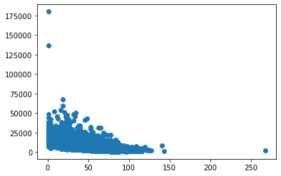

```python
plt.scatter(dataset['Current energy efficiency rating'],  dataset['Total current energy costs over 3 years (£)'])
plt.show()
```

```python
model_x = dataset['Current energy efficiency rating']
model_y = dataset['Total current energy costs over 3 years (£)']
```

```python
model_x = np.array(model_x)
model_y = np.array(model_y)

model_x = model_x.reshape(-1,1)
model_y = model_y.reshape(-1,1)
```

```python
model_eff_costs = LinearRegression().fit(model_x, model_y)
```

```python
model_eff_costs.coef_
```

```
array([[-108.03900306]])
```

```python
model_eff_costs.intercept_
```

```
array([10166.4758954])
```

## Algorithm Challenge 6: Build an algorithm that takes as input the characteristics of a building (any field in the dataset) and outputs recommendations on which elements of the house should be modified to most effectively decrease the total energy cost of the building over a 3-year period

We have shown how the walls and roofs of the buildings could be improved to improve their energy performance in previous sections - see response to algorithm challenges 1, 2, and 4. Using aggregations and LDA, we show that insulation of walls and roofs regardless of wall materials can boost energy efficiency and lower energy costs over 3 years, as shown in algorithm challenge 5.

An appropriate algorithm would build on the results of 1, 2, and 4 to provide guidance on how to boost energy performance as defined by energy efficiency.

Adding insulation appears to be the key to improving energy performance as defined by energy efficiency.